# **Week 4: Chapter Notes - Data Verbs**

Yunjae Choi

February 14, 2017

### **Chapter 8**

Glyphs are created by functions starting with geom_. There are many kinds of glyphs, so there are many geom_ functions: geom_point(), geom_line(), geom_bar(), geom_boxplot(), geom_density(), and so on.

#### *BabyNames Using `ggplot`*

##### Make a Dataset of Only Princes

```r
Princes <-
  BabyNames %>%
  filter(name == "Prince")
```

##### Make it Count vs. Year

```r
the_frame <- ggplot(data = Princes,
                    aes(x = year, y = count))
layer1 <- geom_point(data = Princes,
                     aes(shape = sex))
layer2 <- geom_vline(xintercept = 1978)
```

##### The Final Graph

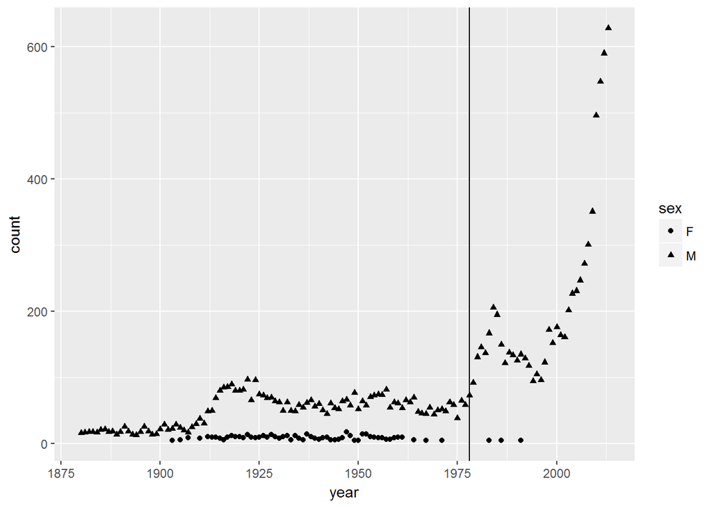

```r
final <-
  Princes %>%
  ggplot(aes(x = year, y = count, shape = sex)) +
  geom_point() +
  geom_vline(xintercept = 1978)
final
```

#### *Heights Using `ggplot`*

```r
Heights <-
  NCHS %>%
  filter( age > 20, ! is.na(smoker)) %>%
  group_by(sex, smoker, age) %>%
  summarise(height = mean(height, na.rm=TRUE))
```

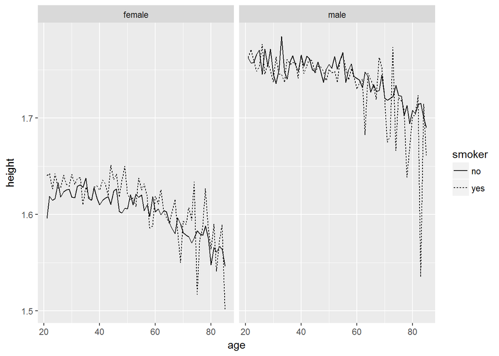

```r
Heights %>%
  ggplot(aes(x = age, y = height)) +
  geom_line(aes(linetype = smoker)) +
  facet_wrap( ~ sex)
```

### **Online Tutorials**

##### *CountryData Using `statisticalModeling` package*

https://dtkaplan.shinyapps.io/Chapter-08-collection/

```r
data(CountryData, package = "DataComputing")
gf_point(death ~ life + alpha:GDPcapita, data = CountryData, verbose = TRUE)
```

```
## ggplot(data = CountryData, aes(y = death, x = life, alpha = GDPcapita)) +
##  geom_point()
```

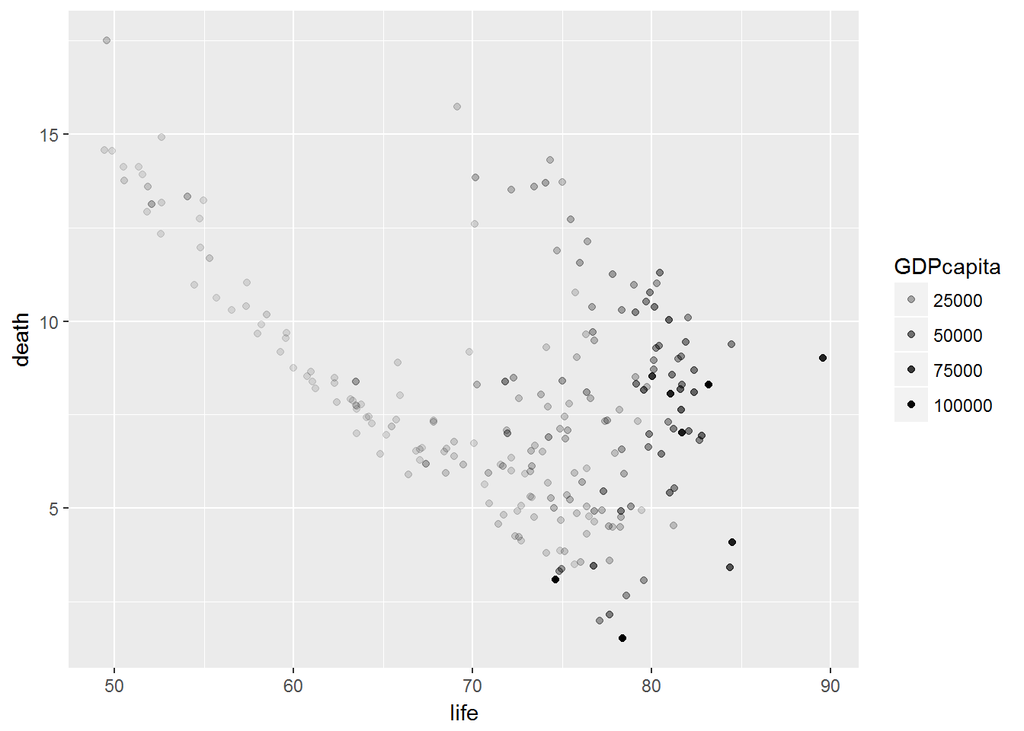

##### *More BabyNames Using `ggplot`*

1. Popular?

```r
data(BabyNames, package = "DataComputing")
BabyNames %>%
  group_by(name) %>%
  summarise(total = n()) %>%
  filter(total >= 265)
```

```
## # A tibble: 29 × 2
##         name total
##        <chr> <int>
## 1       Anna   266
## 2    Charles   267
## 3    Charlie   267
## 4       Cleo   265
## 5  Elizabeth   267
## 6    Frances   265
## 7    Francis   268
## 8     George   266
## 9      Henry   267
## 10       Ira   266
## # ... with 19 more rows
```

2. Popular Ever?

Write a wrangling statement to extract only those names for which there is some year where the total numbers of babies is greater than 50 (combining boys and girls). Your result should look like this: the name followed by the total count in the best year and the year in which that occurred.

```r
BabyNames %>%
  group_by(name) %>%
  summarise(total = n()) %>%
  filter(total == max(total))
```

```
## # A tibble: 16 × 2
##       name total
##      <chr> <int>
## 1  Francis   268
## 2    James   268
## 3     Jean   268
## 4    Jesse   268
## 5   Jessie   268
## 6     John   268
## 7  Johnnie   268
## 8   Joseph   268
## 9      Lee   268
## 10  Leslie   268
## 11  Marion   268
## 12   Ollie   268
## 13  Robert   268
## 14  Sidney   268
## 15  Tommie   268
## 16 William   268
```

3. Popular Forever?

```r
# View(Minneapolis2013)
BabyNames %>%
  filter(count>50) %>%
  group_by(name) %>%
  summarise(nyears = n()) %>%
  filter(nyears >= 80)
```

```
## # A tibble: 1,222 × 2
##        name nyears
##       <chr>  <int>
## 1     Aaron    164
## 2     Abbie    126
## 3      Abel    100
## 4   Abraham    134
## 5       Ada    134
## 6      Adam    147
## 7     Addie    131
## 8     Adela    104
## 9  Adelaide     96
## 10    Adele    132
## # ... with 1,212 more rows
```

##### *Making a Graphics Frame*

Calculate the number of votes for candidates who received more than 10,000 votes altogether.

```r
Minneapolis2013 %>%
  group_by(First) %>%
  summarise(total_votes = n()) %>%
  filter(total_votes > 10000)
```

```
## # A tibble: 2 × 2
##          First total_votes
##          <chr>       <int>
## 1 BETSY HODGES       28935
## 2  MARK ANDREW       19584
```

##### *Counting Babies*

Small subset of BabyNames, 200 randomly selected cases from the years since 2000

```r
SmallSubset <-
  BabyNames %>%
  filter(year > 2000) %>%
  sample_n(size = 200)
```

1. How many babies are represented?

```r
SmallSubset %>%
  summarise(total = sum(count)) # use a reduction verb
```

```
##   total
## 1 21053
```

2. How many babies are there in each year?

```r
SmallSubset %>%
  group_by(year) %>%
  summarise(total = sum(count)) # use a reduction verb
```

```
## # A tibble: 13 × 2
##     year total
##    <int> <int>
## 1   2001  1749
## 2   2002  9256
## 3   2003   311
## 4   2004  1401
## 5   2005  1739
## 6   2006   859
## 7   2007   711
## 8   2008   427
## 9   2009  2126
## 10  2010  1181
## 11  2011    88
## 12  2012   722
## 13  2013   483
```

3. How many distinct names are in each year?

```r
SmallSubset %>%
  group_by(year) %>%
  summarise(total = n_distinct(name)) # use a reduction verb
```

```
## # A tibble: 13 × 2
##     year total
##    <int> <int>
## 1   2001    15
## 2   2002    16
## 3   2003    11
## 4   2004    12
## 5   2005    15
## 6   2006    22
## 7   2007    20
## 8   2008    16
## 9   2009    18
## 10  2010    22
## 11  2011    10
## 12  2012    10
## 13  2013    13
```

4. How many distinct names of each sex are in each year?

```r
SmallSubset %>%
  group_by(year, sex) %>%
  summarise(name_count = n_distinct(name)) # use a reduction verb
```

```
## Source: local data frame [26 x 3]
## Groups: year [?]
##
##     year   sex name_count
##    <int> <chr>      <int>
## 1   2001     F          7
## 2   2001     M          8
## 3   2002     F          8
## 4   2002     M          8
## 5   2003     F          9
## 6   2003     M          2
## 7   2004     F          6
## 8   2004     M          6
## 9   2005     F         10
## 10  2005     M          5
## # ... with 16 more rows
```

##### *Whatever happened to Jane and Mary?*

##### 1. Track the yearly number of Janes and Marys over the years.

```r
Result <-
  BabyNames %>%
  filter(name %in% c("Jane", "Mary")) %>% # keep just the Janes and Marys
  group_by(year, name) %>% # for each year for each name
  summarise(count = sum(count)) %>%
  arrange(desc(name))

Result
```

```
## Source: local data frame [268 x 3]
## Groups: year [134]
##
##     year  name count
##    <int> <chr> <int>
## 1   1880  Mary  7092
## 2   1881  Mary  6948
## 3   1882  Mary  8178
## 4   1883  Mary  8044
## 5   1884  Mary  9253
## 6   1885  Mary  9166
## 7   1886  Mary  9922
## 8   1887  Mary  9935
## 9   1888  Mary 11804
## 10  1889  Mary 11689
## # ... with 258 more rows
```

##### 2. Plot out the result of (1).

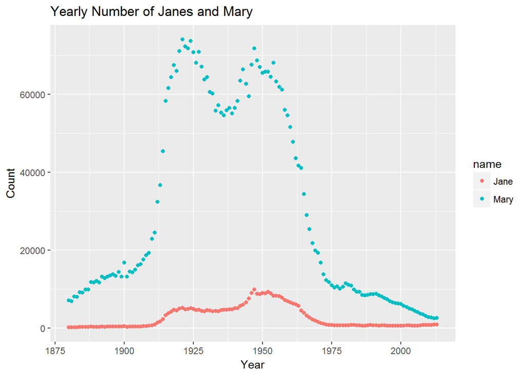

```r
Result %>%
  ggplot(aes(x = year, y = count, color = name)) +
  geom_point() +
  ggtitle("Yearly Number of Janes and Mary") +
  xlab("Year") +
  ylab("Count")
```